# AD2-Problema2

Diego de Lima Pereira

Wednesday, November 05, 2014

Este é um relatório referente a segunda atividade da disciplina de Análise de Dados II, da Universidade Federal de Campina Grande, ministrada pelo professor Nazareno Andrade.

O intuito Geral dessa análise é termos algumas informações sobre músicas, utilizando a base de dados Million Song Subset.

Os dados das musicas estão disponíveis [aqui](http://static.echonest.com/millionsongsubset_full.tar.gz).

Todos os artefatos desse experimento, incluindo o código, extração dos novos dados e resultados, podem ser encontradas no meu repositório do github [aqui](https://github.com/DiegoPereira/ad2-problema2).

**1. O Rock está realmente morrendo?**

Comumente ouvimos frases similares ao título dessa seção, não só relacionado ao rock propriamente dito, mas a todos os outros gêneros tradicionais. Com a ascensão de novos gêneros (como Happy rock por exemplo), maior número de músicas lançadas por ano e o nosso maior acesso a elas, não é tão estranha a sensação de que o tradicional está morrendo.

Foram selecionados 5 gêneros tradicionais(country, rock, reggae, pop e jazz) e veio a pergunta: O número de lançamentos desses gêneros vem realmente diminuindo?

No gráfico abaixo, podemos observar que não é bem assim, o número de músicas dos gêneros tradicionais, apesar de pequenas quedas, tende a aumentar significativamente, como é o caso do rock e do pop. Para reggae e jazz, valores são praticamente constantes (apesar de uma mudança significativa na década de 90). Destacamos o country, assim como o sertanejo brasileiro, passam por alguns anos de “esquecimento” porém há épocas em que voltam a ser tendência.

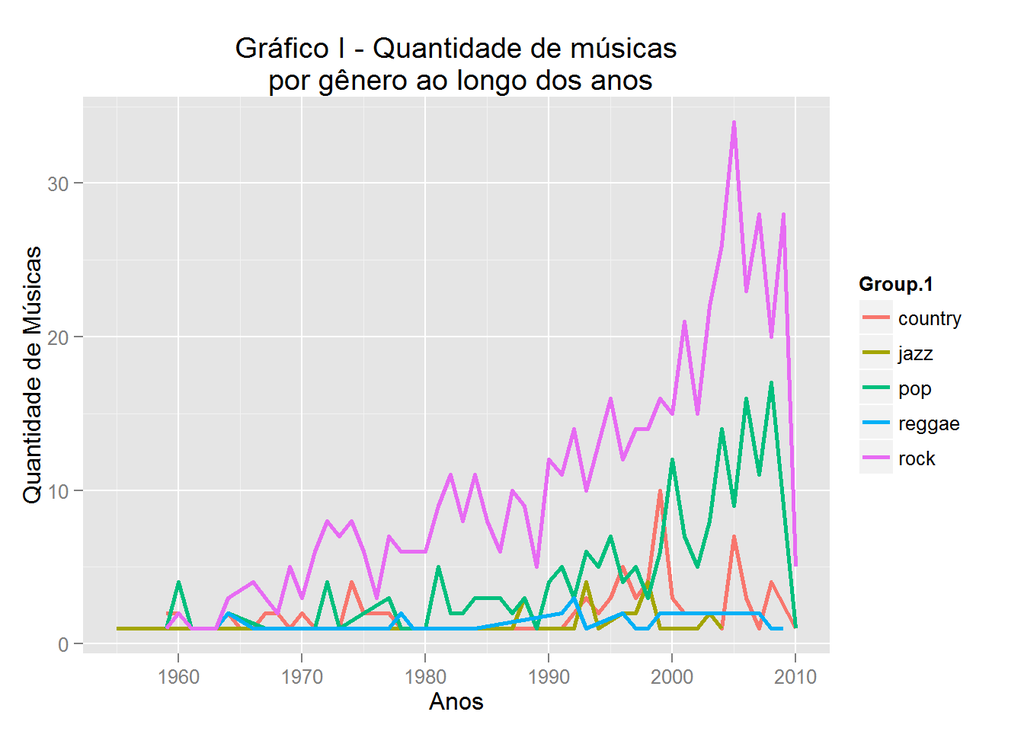

**2. As músicas estão mais curtas ou mais longas com o passar do tempo?**

Primeiramente, abaixo está um gráfico que relaciona o Gráfico I com o tempo das músicas. Na horizontal temos os anos, na vertical temos a duração média em segundos, a cor da bolha indica o gênero e seu tamanho indica a quantidade de músicas lançadas.

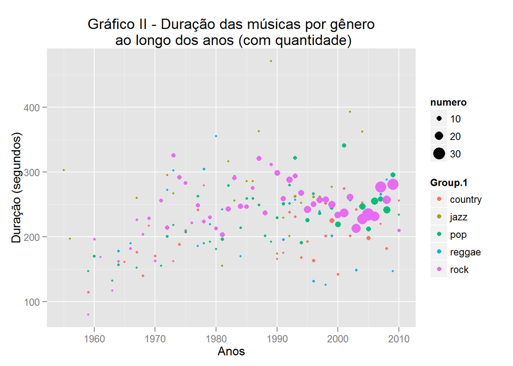

Apesar das informações citadas anteriormente, o tamanho da bolha chama muito a atenção podemos levar a interpretações equivocadas dos leitores.

Devido a isso, temos outra versão do gráfico com tamanho contante dos circulos(Figura III).

Para os observadores um pouco mais criteriosos, percebe-se que a distribuição até em torno dos anos 2000 se assemelha a uma parábola. Possui ascensão entre as décadas de 60 e 80, ápice entre 80 e 90 e uma queda após isso, porém por volta de 2005 volta a subir.

Não podemos afirmar que a duração das músicas está seguindo alguma tendência (para maior ou menor). Podemos tentar reconhecer alguns padrões, porém nada muito conclusivo e de maneira alguma podemos inferir a tendência média de minutos para daqui a 10 anos por exemplo.

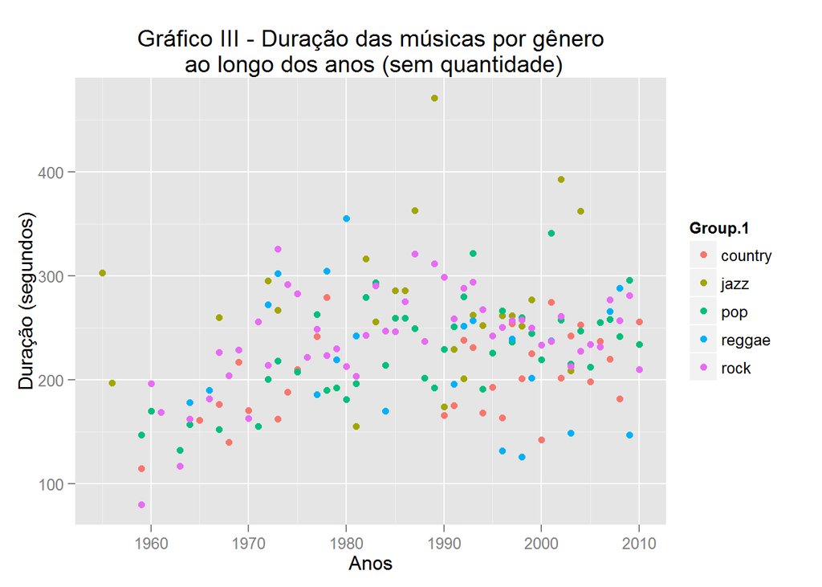